# EDA Compass

Hubert Baniecki, Łukasz Brzozowski, Szymon Maksymiuk

19.03.2019

# 1 Wstęp

Prezentujemy dane pochodzące z bazy używanej w systemie COMPAS - Correctional Offender Management Profiling for Alternative Sanctions, używanej przez sędziów i policję do oceny prawdopodobieństwa, że zatrzymany zostanie recydywistą, tj. ponownie popełni przestępstwo (na przestrzeni 2 lat od wyjścia na wolność). Dane dotyczą przestępstw dokonanych w Broward County na Florydzie. Na podstawie danych przygotujemy model klasyfikacyjny służący do przewidywania, czy dany przestępca popełni przestępstwo - kolumną celu w ramce jest `is_recid`.

```r
enc <- guess_encoding("cox-violent-parsed.csv", n_max = 10000)[[1]]
dane <- as.data.frame(read_csv("cox-violent-parsed.csv", locale = locale(encoding = enc[1])))

df <- select(dane, sex, age, age_cat, race, juv_fel_count, juv_misd_count, juv_other_count, priors_count, c_charge_degree, c_charge_desc, c_jail_in, c_jail_out, is_recid, days_b_screening_arrest)

df <- df %>% distinct()
df[df == ""] <- NA
df <- na.omit(df)

df$c_jail_in <- as.Date(substring(df$c_jail_in, 1, 10),
                              format = "%d/%m/%Y")
df$c_jail_out <- as.Date(substring(df$c_jail_out, 1, 10),
                              format = "%d/%m/%Y")

df$jailLength <- as.numeric(as.Date(df$c_jail_out) - as.Date(df$c_jail_in))

df <- df %>% filter(jailLength!=0) %>%
        filter(days_b_screening_arrest <= 30) %>%
        filter(days_b_screening_arrest >= -30) %>%
        select(-days_b_screening_arrest, -c_jail_in, -c_jail_out) %>%
        filter(is_recid!=-1) %>%
        filter(c_charge_degree != "O")

d <- as.data.frame(unclass(df))
colnames(d) <- c("sex", "age", "ageCat", "race", "juvFel", "juvMisd", "juvOther", "priors", "chargeDegree", "chargeDesc", "isRecid", "jailLength")
```

# 2 Zmienne

Ze zbioru danych wybraliśmy 14 zmiennych w tym target czyli `isRecid`. Usunęliśmy nieunikalne wartości oraz brakujące dane. Pozbyliśmy się też danych błędnych, np. gdy zatrzymany spędził w więzieniu 0 dni, i danych, które zaszumiłyby klasyfikację - wartości `-1` w kolumnie celu oznaczające brak danych. Po oczyszczeniu danych otrzymaliśmy ramkę zawierającą 7850 unikalnych wierszy.

## 2.1 Opis kolumn

- `sex` - płeć zatrzymanego
- `race` - rasa
- `age` - wiek w latach
- `ageCat` - kategoria wiekowa
- `juvFel` - liczba poważnych przestępstw jako nieletni
- `juvMisd` - liczba wykroczeń jako nieletni
- `juvOther` - liczba innych aktów kryminalnych jako nieletni
- `priors` - liczba wyroków
- `chargeDegree` - stopień przestępstwa
- `chargeDesc` - opis przestępstwa
- `jailLength` - długość pobytu w więzieniu
- `isRecid` - kolumna celu

# 3 Rozkłady zmiennych

## 3.1 isRecid

Rozkład targetu `isRecid`.

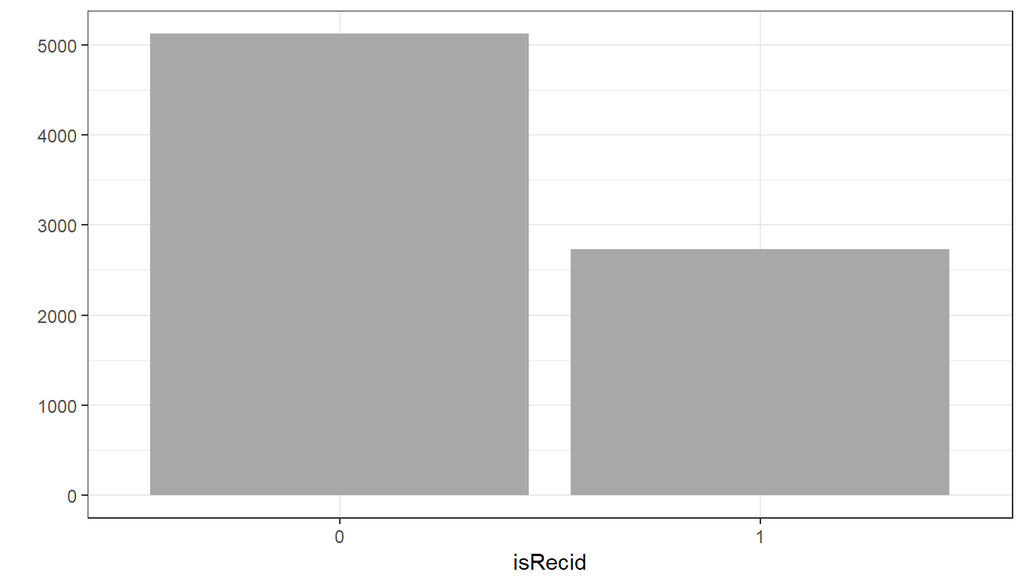

```r
temp <- select(d,isRecid, age)
temp3 <- as.data.frame(table(temp$isRecid)); temp3$Var1 <- factor(temp3$Var1, levels = temp3$Var1[rev(order(temp3$Freq))])
ggplot(temp3, aes(x=Var1, y=Freq)) + geom_bar(stat="identity",fill = "darkgrey") + xlab("isRecid") + ylab("") + theme_bw()
```

## 3.2 sex, race, age i ageCat

Zmiennymi opisującymi konkretnego człowieka jest jego płeć, wiek oraz rasa. Przyjrzyjmy się ich rozkładom.

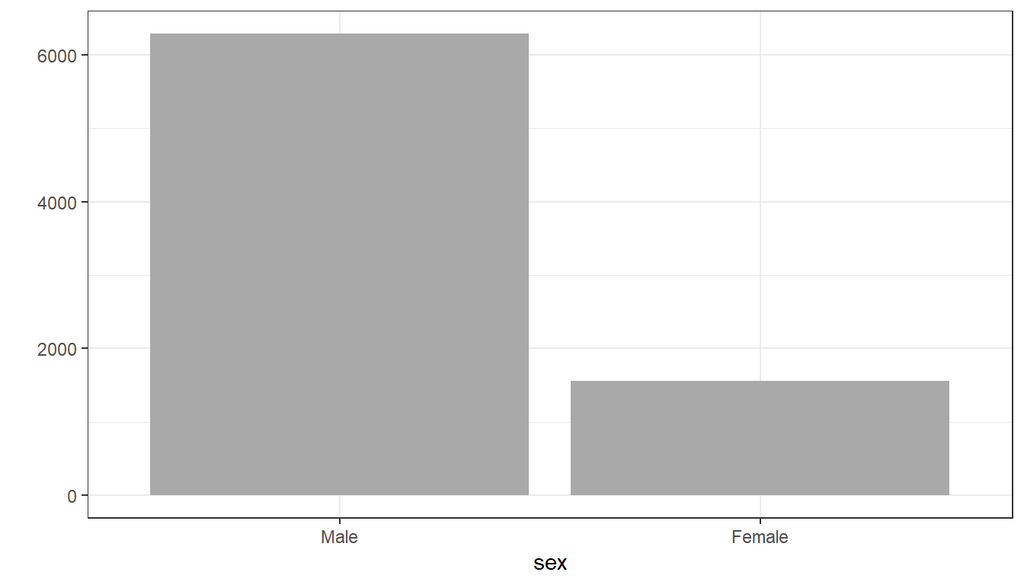

```r
temp <- select(d,sex, ageCat, race, isRecid)
temp0 <- as.data.frame(table(temp$sex)); temp0$Var1 <- factor(temp0$Var1, levels = temp0$Var1[rev(order(temp0$Freq))])
ggplot(temp0, aes(x=Var1, y=Freq)) + geom_bar(stat="identity",fill = "darkgrey") + xlab("sex") + ylab("") + theme_bw()
```

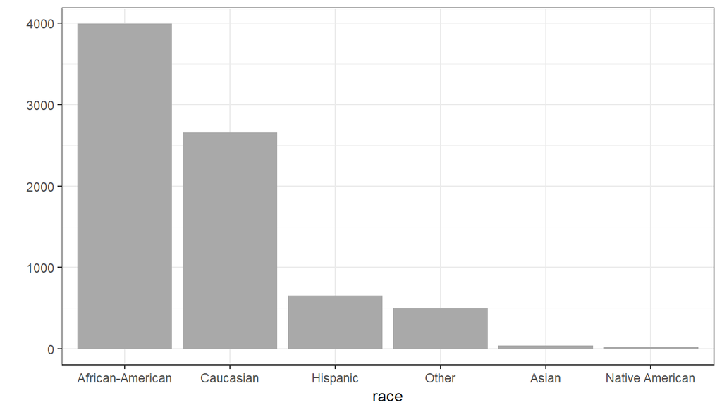

```r
temp1 <- as.data.frame(table(temp$race)); temp1$Var1 <- factor(temp1$Var1, levels = temp1$Var1[rev(order(temp1$Freq))])
ggplot(temp1, aes(x=Var1, y=Freq)) + geom_bar(stat="identity",fill = "darkgrey") + xlab("race") + ylab("") + theme_bw()
```

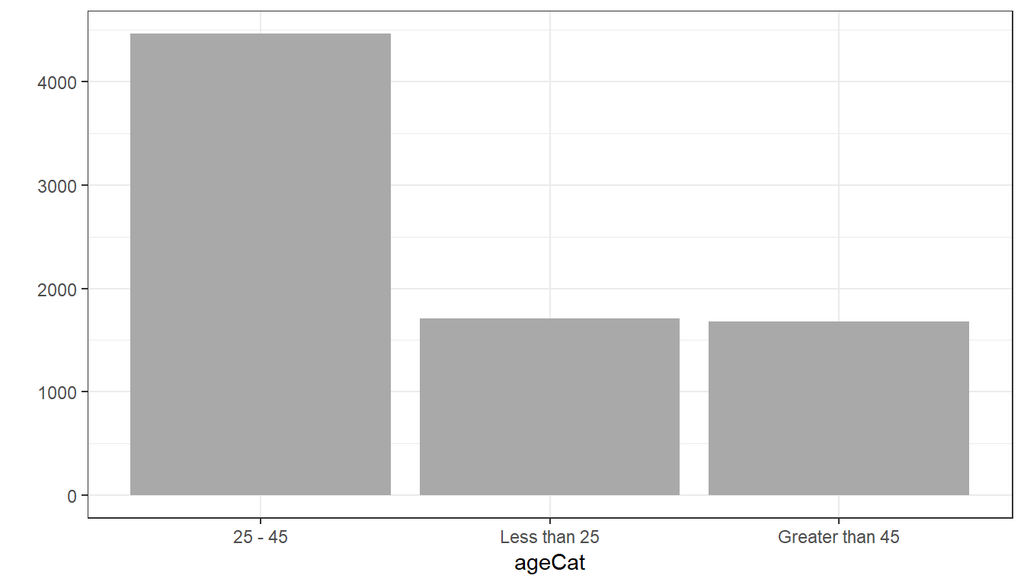

```r
temp2 <- as.data.frame(table(temp$ageCat)); temp2$Var1 <- factor(temp2$Var1, levels = temp2$Var1[rev(order(temp2$Freq))])
ggplot(temp2, aes(x=Var1, y=Freq)) + geom_bar(stat="identity",fill = "darkgrey") + xlab("ageCat") + ylab("") + theme_bw()
```

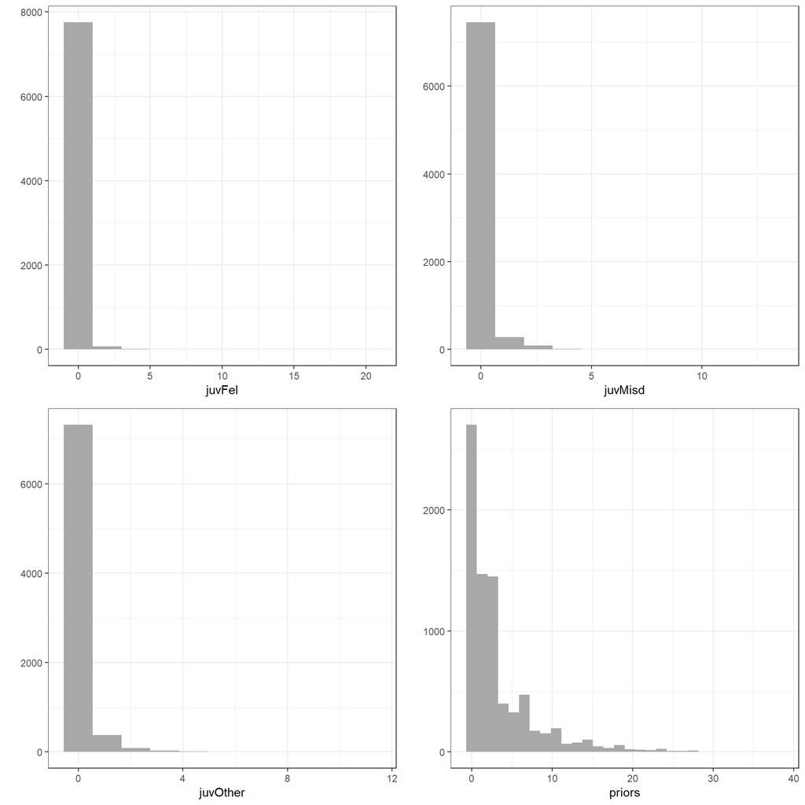

```r
temp <- select(d, juvFel, juvMisd, juvOther, priors)
summary(temp)
plot1 <- ggplot(temp, aes(x = juvFel)) +
  geom_histogram(fill = "darkgrey", bins = 11) + theme_bw() + ylab("")
plot2 <- ggplot(temp, aes(x = juvMisd)) +
  geom_histogram(fill = "darkgrey", bins = 11) + theme_bw() + ylab("")
plot3 <- ggplot(temp, aes(x = juvOther)) +
  geom_histogram(fill = "darkgrey", bins = 11) + theme_bw() + ylab("")
plot4 <- ggplot(temp, aes(x = priors)) +
  geom_histogram(fill = "darkgrey") + theme_bw() + ylab("")

grid.arrange(plot1, plot2, plot3, plot4, ncol=2,nrow=2)
```

## 3.4 chargeDegree i chargeDesc

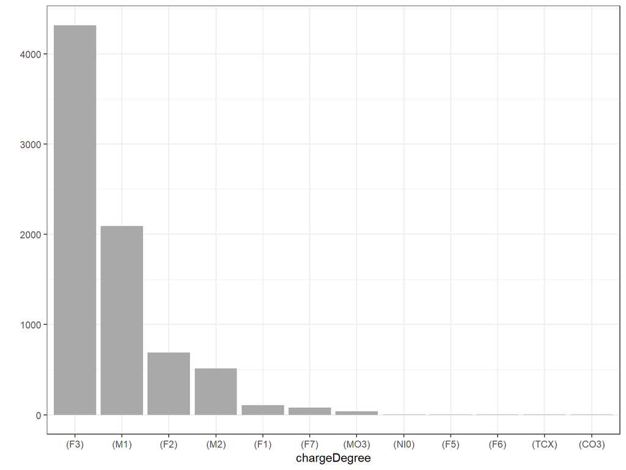

```r
d$chargeDegree <- as.factor(d$chargeDegree)
d$chargeDesc <- as.factor(d$chargeDesc)
temp <- select(d, chargeDegree, chargeDesc)
temp0 <- as.data.frame(table(temp$chargeDegree)); temp0$Var1 <- factor(temp0$Var1, levels = temp0$Var1[rev(order(temp0$Freq))])
ggplot(temp0, aes(x=Var1, y=Freq)) + geom_bar(stat="identity",fill = "darkgrey") + xlab("chargeDegree") + ylab("") + theme_bw()
```

Jak widzimy, wśród dostępnych obserwacji najczęściej pojawiają się F3 - przestępstwo 3. stopnia oraz M1 - wykroczenie 1. stopnia. Przykładowymi wykroczeniami F3 są kradzież samochodu, posiadanie twardych narkotyków czy prowadzenie pojazdu pod wpływem alkoholu. Do wykroczeń M1 należą zaś m.in. jednokrotna przemoc domowa, posiadanie broni bez pozwolenia oraz drobne kradzieże.

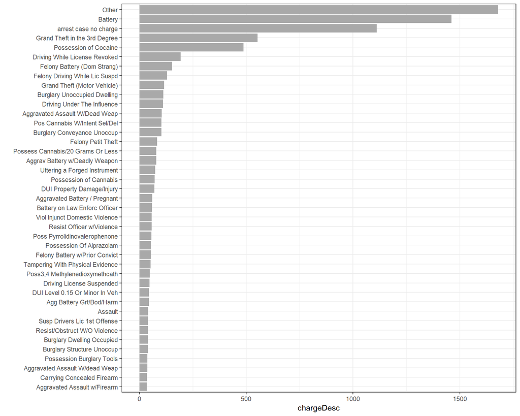

```r
temp$chargeDesc <- fct_lump(temp$chargeDesc, 40)
temp0 <- as.data.frame(table(temp$chargeDesc)); temp0$Var1 <- factor(temp0$Var1, levels = temp0$Var1[(order(temp0$Freq))])
ggplot(temp0, aes(x=Var1, y=Freq)) + geom_bar(stat="identity",fill = "darkgrey") + ylab("chargeDesc") + xlab("") + theme_bw() + coord_flip()
```

Możemy zauważyć, że w bazie danych występuje znaczna liczba unikalnych opisów przestępstw. W szczególności najwięcej przestępstw zakategoryzowano jako `Other`, co uniemożliwia dobrą predykcję recydywistów na podstawie tej kolumny.

# 4 Korelacje

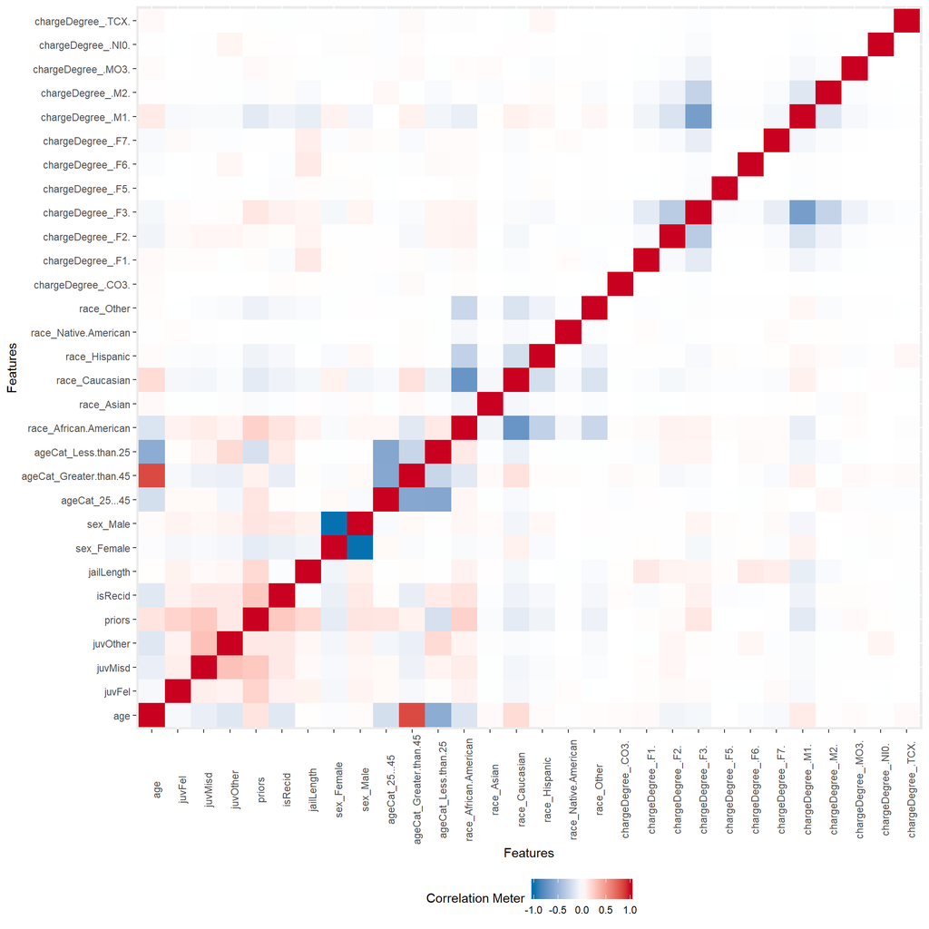

```r
temp <- select(d, -chargeDesc)
plot_correlation(temp, maxcat = 12L)
```

Powyżej przedstawiamy wykres korelacji zmiennych w tabeli. Poza oczywistymi korelacjami `age ~ ageCat` czy zależności pomiędzy rasami, możemy zauważyć niewielkie korelacje kolumn `juvMisd`, `juvOther` i `priors`.

# 5 Zależności dwuwymiarowe

Jak widzimy, znaczna część danych dotyczy mężczyzn, Afroamerykanów oraz osób w przedziale wiekowym 25-45. W szczególność zauważmy, że aż 1890 osób z 7850 obserwacji należy do każdej z powyższyczh trzech grup. Druga najliczniejsza grupa różni się tylko rasą, dotyczy bowiem białych mężczyzn z przedziału wiekowego 25-45.

```r
temp <- select(d, ageCat, sex, race) %>% filter(ageCat == "Less than 25", sex == "Female")
temp1 <- select(d, ageCat, sex, race) %>% filter(ageCat == "Less than 25", sex == "Male")
temp2 <- select(d, ageCat, sex, race) %>% filter(ageCat == "25 - 45", sex == "Female")
temp3 <- select(d, ageCat, sex, race) %>% filter(ageCat == "25 - 45", sex == "Male")
temp4 <- select(d, ageCat, sex, race) %>% filter(ageCat == "Greater than 45", sex == "Female")
temp5 <- select(d, ageCat, sex, race) %>% filter(ageCat == "Greater than 45", sex == "Male")

dt <- cbind("Female" = table(temp$race), "Male" = table(temp1$race), "Female" = table(temp2$race), "Male" = table(temp3$race), "Female" = table(temp4$race), "Male" = table(temp5$race)) %>% as.data.frame()
kable(dt) %>%
  kable_styling(c("striped", "bordered")) %>%
  add_header_above(c(" ", "Less than 25" = 2, "25 - 45" = 2, "Greater than 45" = 2))
```

|  | Less than 25 Female | Less than 25 Male | 25 - 45 Female | 25 - 45 Male | Greater than 45 Female | Greater than 45 Male |
| --- | --- | --- | --- | --- | --- | --- |
| African-American | 194 | 834 | 455 | 1890 | 89 | 530 |
| Asian | 1 | 4 | 2 | 18 | 1 | 13 |
| Caucasian | 91 | 344 | 363 | 1078 | 168 | 611 |
| Hispanic | 23 | 113 | 59 | 303 | 21 | 133 |
| Native American | 0 | 3 | 2 | 9 | 2 | 4 |
| Other | 21 | 79 | 53 | 229 | 17 | 93 |

Warto spojrzeć szerzej na wspomnianą wcześniej kolumnę chargeDegree, tym razem w kontekście potencjalnego związku z kolumną jailLength, a więc długością pobytu w więzieniu. Sprawdźmy więc średnią długość zatrzymania dla każdego ze stopni przestępstwa.

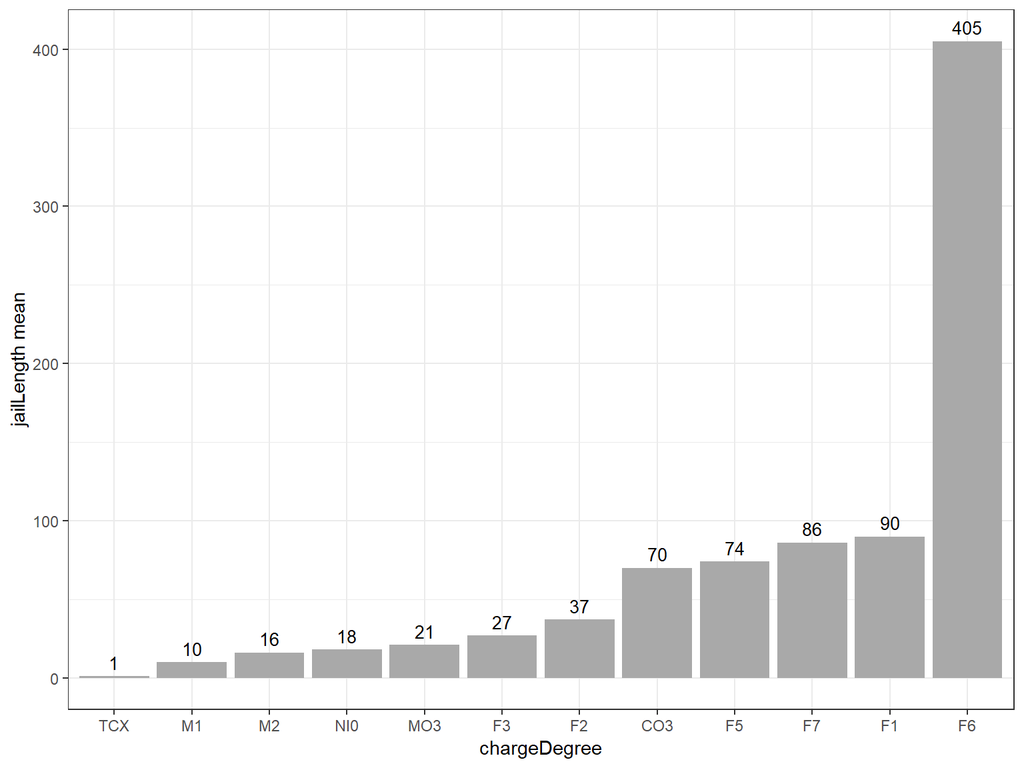

```r
tmp <- rbind(c("CO3", d[d$chargeDegree == "(CO3)",]$jailLength%>%mean()),
      c("F1", d[d$chargeDegree == "(F1)",]$jailLength%>%mean()),
      c("F2", d[d$chargeDegree == "(F2)",]$jailLength%>%mean()),
      c("F3", d[d$chargeDegree == "(F3)",]$jailLength%>%mean()),
      c("F5", d[d$chargeDegree == "(F5)",]$jailLength%>%mean()),
      c("F6", d[d$chargeDegree == "(F6)",]$jailLength%>%mean()),
      c("F7", d[d$chargeDegree == "(F7)",]$jailLength%>%mean()),
      c("M1", d[d$chargeDegree == "(M1)",]$jailLength%>%mean()),
      c("M2", d[d$chargeDegree == "(M2)",]$jailLength%>%mean()),
      c("MO3", d[d$chargeDegree == "(MO3)",]$jailLength%>%mean()),
      c("NI0", d[d$chargeDegree == "(NI0)",]$jailLength%>%mean()),
      c("TCX", d[d$chargeDegree == "(TCX)",]$jailLength%>%mean())
      )
tmp <- as.data.frame(tmp)
tmp$V2 <- round(as.numeric(as.character(tmp$V2)), 0)
ggplot(data=tmp, aes(x=reorder(V1,V2),V2), y=V2) +
  geom_bar(stat="identity", fill="darkgrey")+
  geom_text(aes(label=V2), vjust=-0.5, color="black", size=3.5)+
  labs(x = "chargeDegree", y = "jailLength mean")+
  theme_bw()
```

Zostaniemy przy temacie kategorii przestępstw, lecz teraz przeanalizujemy to w kontekście recydywistów. Mianowicie sprawdźmy, czy któraś kategoria może nam powiedzieć więcej o ryzyku recydywy.

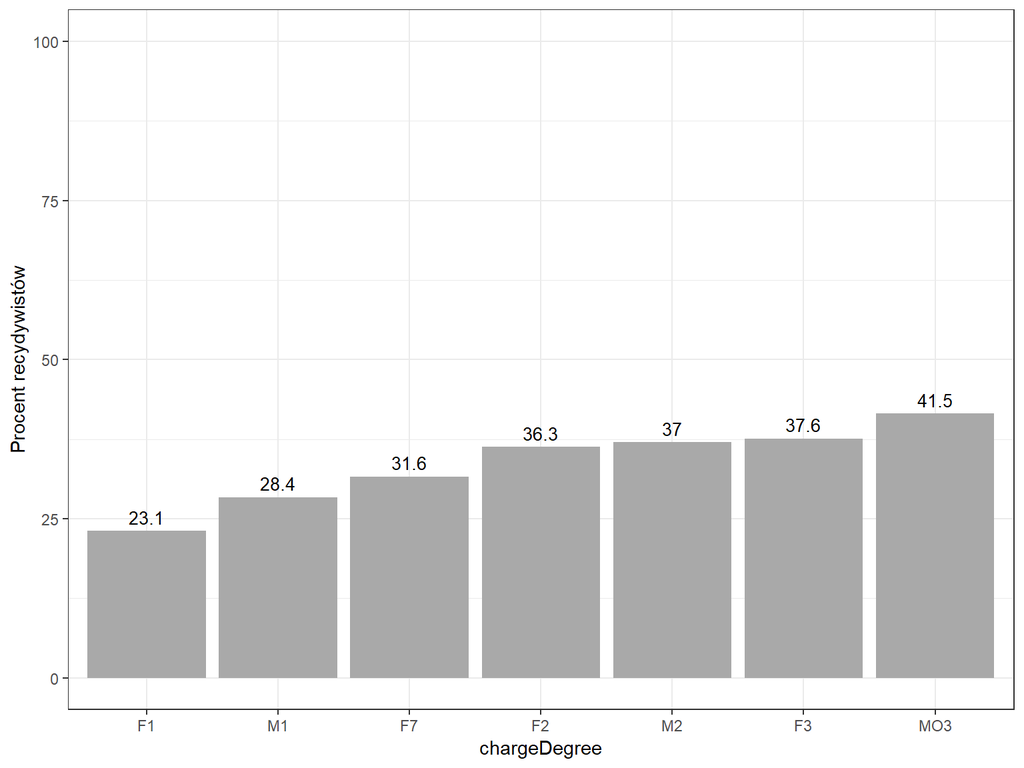

```r
c(
  round(100*(select(d, chargeDegree, isRecid) %>% filter(chargeDegree == "(F1)", isRecid == "1") %>% nrow())/(select(d, chargeDegree, isRecid) %>% filter(chargeDegree == "(F1)") %>% nrow()), 1),
    round(100*(select(d, chargeDegree, isRecid) %>% filter(chargeDegree == "(F2)", isRecid == "1") %>% nrow())/(select(d, chargeDegree, isRecid) %>% filter(chargeDegree == "(F2)") %>% nrow()), 1),
    round(100*(select(d, chargeDegree, isRecid) %>% filter(chargeDegree == "(F3)", isRecid == "1") %>% nrow())/(select(d, chargeDegree, isRecid) %>% filter(chargeDegree == "(F3)") %>% nrow()), 1),


    round(100*(select(d, chargeDegree, isRecid) %>% filter(chargeDegree == "(F7)", isRecid == "1") %>% nrow())/(select(d, chargeDegree, isRecid) %>% filter(chargeDegree == "(F7)") %>% nrow()), 1),
    round(100*(select(d, chargeDegree, isRecid) %>% filter(chargeDegree == "(M1)", isRecid == "1") %>% nrow())/(select(d, chargeDegree, isRecid) %>% filter(chargeDegree == "(M1)") %>% nrow()), 1),
    round(100*(select(d, chargeDegree, isRecid) %>% filter(chargeDegree == "(M2)", isRecid == "1") %>% nrow())/(select(d, chargeDegree, isRecid) %>% filter(chargeDegree == "(M2)") %>% nrow()), 1),
    round(100*(select(d, chargeDegree, isRecid) %>% filter(chargeDegree == "(MO3)", isRecid == "1") %>% nrow())/(select(d, chargeDegree, isRecid) %>% filter(chargeDegree == "(MO3)") %>% nrow()), 1)

) -> perc
nam <- c("F1", "F2", "F3", "F7", "M1", "M2", "MO3")
tmp <- as.data.frame(cbind(nam, perc))
tmp$perc <- as.numeric(as.character(tmp$perc))
ggplot(data=tmp, aes(x=reorder(nam,perc),perc), y=perc) +
  geom_bar(stat="identity", fill="darkgrey")+
  geom_text(aes(label=perc), vjust=-0.5, color="black", size=3.5)+
  scale_y_continuous(limits = c(0, 100))+
  labs(x = "chargeDegree", y = "Procent recydywistów")+
  theme_bw()
```

Jak widać istenieje pewna zależność pomiędzy stopniem przestępstwa, a ryzkiem powrotu do recydywy. Żadna nie jest jednak na tyle spektakularna, gdyż teoretycznie wciąż losowanie lepiej przewidziałoby czy ktoś będzie recydywistą, niż bazowanie tylko na kategori. Niemniej jest to ciekawy punkt wyjścia.

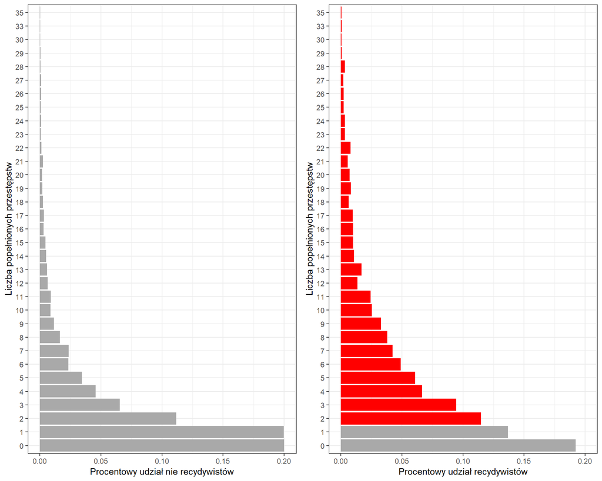

```r
suma <- d %>% mutate(sum = juvFel + juvMisd + juvOther + priors) %>% select(sum , isRecid, jailLength)
temp <- as.data.frame(table(suma$sum))

temp0 <- as.data.frame(table(filter(suma, isRecid==0)$sum))
temp1 <- as.data.frame(table(filter(suma, isRecid==1)$sum))
wektor <- as.numeric(Reduce(intersect, list(temp0$Var1, temp1$Var1)))
temp0 <- filter(temp0, Var1 %in% wektor)
temp1 <- filter(temp1, Var1 %in% wektor)

temp0 <- mutate(temp0, percent = Freq/(sum(Freq)))
temp1 <- mutate(temp1, percent = Freq/(sum(Freq)))

temp0[1,3] <- 0.20
color <- ifelse(temp0$percent>temp1$percent, "darkgrey", "red")
temp1$color <- color
plot2 <- ggplot(temp0, aes(x = Var1, y = percent)) + coord_flip() + ylim(0,0.2) + theme_bw() +
  geom_bar(stat="identity",fill = "darkgrey") + ylab("Procentowy udział nie recydywistów") + xlab("Liczba popełnionych przestępstw")
plot3 <- ggplot(temp1, aes(x = Var1, y = percent)) + coord_flip() + ylim(0,0.2) + theme_bw() +
  geom_bar(stat="identity",fill = color) + ylab("Procentowy udział recydywistów") + xlab("Liczba popełnionych przestępstw")

grid.arrange(plot2, plot3, ncol=2,nrow=1)
```

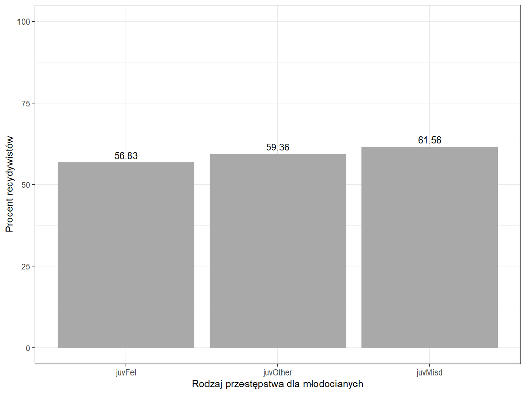

```r
tmp <- as.data.frame(cbind("nam" = c("juvFel", "juvMisd", "juvOther"), "perc" = round(100*c(
  (d[d$juvFel > 0,] %>% filter(isRecid == "1") %>% nrow())/nrow(d[d$juvFel > 0,]),
  (d[d$juvMisd > 0,] %>% filter(isRecid == "1") %>% nrow())/nrow(d[d$juvMisd > 0,]),
  (d[d$juvOther > 0,] %>% filter(isRecid == "1") %>% nrow())/nrow(d[d$juvOther > 0,])
  ), 2)))
tmp$perc <- as.numeric(as.character(tmp$perc))

ggplot(data=tmp, aes(x=reorder(nam,perc),perc), y=perc) +
  geom_bar(stat="identity", fill="darkgrey")+
  geom_text(aes(label=perc), vjust=-0.5, color="black", size=3.5)+
  scale_y_continuous(limits = c(0, 100))+
  labs(x = "Rodzaj przestępstwa dla młodocianych", y = "Procent recydywistów")+
  theme_bw()
```

# 6 Podsumowanie

Po usunięciu nieistotnych z punktu widzenia modelu kolumn otrzymujemy dobrą do modelowania ramkę danych o niskim stopniu skorelowania danych. Możemy zaobserwować silną przewagę rekordów dotyczących mężczyzn w wieku 25-45, co będzie należało wziąć pod uwagę w szczególności przygotowania zbiorów walidacyjnego i testowego. Należy także pamiętać, że każdy stopień przestępstwa cechuje się okresem, na który można skazać przestępcę na pozbawienie wolności, zatem kolumny `jailLength` oraz `chargeDegree` pozostają niejawnie skorelowane.